# Project

```python
import pandas as pd
import numpy as np
import seaborn as sns
import matplotlib.pyplot as plt
from statsmodels.tsa.arima.model import ARIMA
from sklearn.metrics import mean_squared_error
import warnings
warnings.filterwarnings("ignore")
```

**Data Preprocessing**

After importing the dataset we proceed to bring it to a suitable format for further analysis. This involves converting some columns to appropriate data types and deciding on handling missing values if present. Each step is commented in the code that follows.

```python
# Load the preprocessed time series data into a pandas DataFrame
data = pd.read_csv('drive/MyDrive/Colab Notebooks/exchange_rates.csv')
print(data.head())

# delete 1st column of indexes from df
data = data.drop(data.columns[[0]], axis=1)

# Handle missing values
data.dropna(inplace=True)  # Remove rows with missing values

# Convert 'date' column to datetime format
data['date'] = pd.to_datetime(data['date'])

# Convert 'сurrency' column to categorical data type
data['сurrency'] = data['currency'].astype('category')

# Sort df by values and by date
data.sort_values(by=['currency', 'date'], inplace=True)

# Reset the index of the DataFrame
data.reset_index(drop=True, inplace=True)
print(data)
```

```
   Unnamed: 0     Country/Currency currency       value        date
0           0     Australia Dollar      AUD    1.581627  17/12/2021
1           1  Great Britain Pound      GBP    0.851619  17/12/2021
2           2                 Euro      EUR    1.000000  17/12/2021
3           3            Japan Yen      JPY  128.301759  17/12/2021
4           4    Switzerland Franc      CHF    1.041015  17/12/2021
                  Country/Currency currency        value       date сurrency
0      United Arab Emirates Dirham      AED     4.159826 2021-12-17      AED
1      United Arab Emirates Dirham      AED     4.127870 2021-12-18      AED
2      United Arab Emirates Dirham      AED     4.127870 2021-12-19      AED
3      United Arab Emirates Dirham      AED     4.130046 2021-12-20      AED
4      United Arab Emirates Dirham      AED     4.144655 2021-12-21      AED
...                            ...      ...          ...        ...      ...
85329                Zambia Kwacha      ZMK  9632.617646 2023-12-02      ZMK
85330                Zambia Kwacha      ZMK  9593.055745 2023-12-03      ZMK
85331                Zambia Kwacha      ZMK  9826.335123 2023-12-04      ZMK
85332                Zambia Kwacha      ZMK  9825.247432 2023-12-05      ZMK
85333                Zambia Kwacha      ZMK  9672.151284 2023-12-06      ZMK

[85334 rows x 5 columns]
```

**Daily Percentage Changes**

For each currency pair the daily percentage change in exchange rates is computed. This is done by taking the difference between the current day's exchange rate and the previous day's exchange rate, divided by the previous day's exchange rate.

```python
# daily percentage change

# multipl by 100 yields percentages
# groupby('currency') groups by currency,
# ['value'] specifies the column for calculation

data['DailyPercentageChange'] = data.groupby('currency')['value'].pct_change() * 100
print(data)
```

```
                  Country/Currency currency        value       date сurrency  \
0      United Arab Emirates Dirham      AED     4.159826 2021-12-17      AED
1      United Arab Emirates Dirham      AED     4.127870 2021-12-18      AED
2      United Arab Emirates Dirham      AED     4.127870 2021-12-19      AED
3      United Arab Emirates Dirham      AED     4.130046 2021-12-20      AED
4      United Arab Emirates Dirham      AED     4.144655 2021-12-21      AED
...                            ...      ...          ...        ...      ...
85329                Zambia Kwacha      ZMK  9632.617646 2023-12-02      ZMK
85330                Zambia Kwacha      ZMK  9593.055745 2023-12-03      ZMK
85331                Zambia Kwacha      ZMK  9826.335123 2023-12-04      ZMK
85332                Zambia Kwacha      ZMK  9825.247432 2023-12-05      ZMK
85333                Zambia Kwacha      ZMK  9672.151284 2023-12-06      ZMK

       DailyPercentageChange
0                        NaN
1                  -0.768205
2                   0.000000
3                   0.052715
4                   0.353725
...                      ...
85329              -0.634619
85330              -0.410708
85331               2.431753
85332              -0.011069
85333              -1.558191

[85334 rows x 6 columns]
```

**Descriptive Statistics**

Next, some descriptive statistics for the daily percentage change in exchange rates are computed. These statistics provide information as to the central tendency, spread, and shape of the distribution of percentage changes.

```python
# Compute descriptive statistics
statistics = data['DailyPercentageChange'].describe()
skewness = data['DailyPercentageChange'].skew()
kurtosis = data['DailyPercentageChange'].kurtosis()

print("Descriptive Statistics:")
print(statistics)
print("Skewness: {:.4f}".format(skewness))
print("Kurtosis: {:.4f}".format(kurtosis))
```

```
Descriptive Statistics:
count     85184.000000
mean          7.580897
std        1732.122626
min         -99.979926
25%          -0.526433
50%           0.000000
75%           0.525527
max      492372.446034
Name: DailyPercentageChange, dtype: float64
Skewness: 272.9707
Kurtosis: 76865.5225
```

Out of curiosity, we want to determine the observation with the maximally observed change:

```python
# Currency with max daily percentage change
# use idxmax() to retrieve the index of the maximum value,
# then access corresponding 'currency' value in the DataFrame

currency_with_max_change = data.loc[data['DailyPercentageChange'].idxmax()]
print(currency_with_max_change)
```

```
Country/Currency            Malaysia Ringgit
currency                                 MYR
value                           22390.919672
date                     2022-09-22 00:00:00
сurrency                                 MYR
DailyPercentageChange          492372.446034
Name: 53756, dtype: object
```

Since the values of the Malaysia Ringgit right before and after 22 Sep 2022 are around 4.55 and 4.49 respectively, the very high value could be an outlier resulting by mistaken data encoding or similar.

**Identify Periods of High Volatility**

Next we apply statistical techniques in order to identify periods of high volatility in the exchange rates. This analysis can help uncover specific time periods when the exchange rates experienced significant fluctuations.

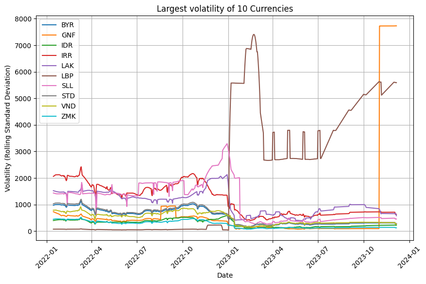

```python
# Calculate the volatility (rolling standard deviation) for each currency pair
window_size = 30  # Adjust the window size
data['volatility'] = data.groupby('currency')['value'].rolling(window_size).std().droplevel(0)

# Select a subset of currencies based on volatility
top_currencies = data.groupby('currency')['volatility'].mean().nlargest(10).index

# Filter the data for the selected currencies
subset_data = data[data['currency'].isin(top_currencies)]

# Plot the volatility for the selected currencies
fig, ax = plt.subplots(figsize=(10, 6))
for currency, df in subset_data.groupby('currency'):
    ax.plot(df['date'], df['volatility'], label=currency)

ax.set_xlabel('Date')
ax.set_ylabel('Volatility (Rolling Standard Deviation)')
ax.set_title('Largest volatility of 10 Currencies')
ax.legend()
ax.grid(True)
plt.xticks(rotation=45)

plt.show()
```

For each currency pair the volatility (rolling standard deviation) is calculated using the `rolling()` method with a specified window size. This gives us a measure of the fluctuations in exchange rates over time.

In this example, we choose the top 10 currencies with the highest average volatility and the data is filtered to include only the selected currencies in the `subset_data` DataFrame.

Volatility over time for the selected currencies is plotted using a line plot. The x-axis represents the date, and the y-axis represents the volatility.

**Correlation Analysis**

In order to investigate the relationship between the top 10 currencies with the highest average volatility we perform correlation analysis. This is here done using Pearson's correlation coefficient to measure the strength and direction of association between the pairs.

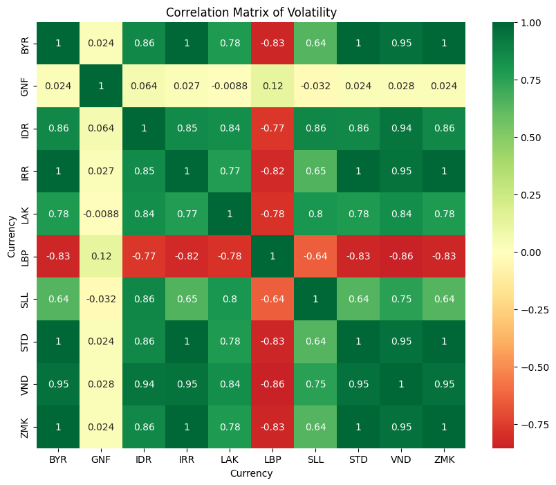

```python
# Create a pivot table for correlation analysis
correlation_data = subset_data.pivot_table(index='date', columns='currency', values='volatility', aggfunc='mean')

# Calculate correlation coefficients
correlation_matrix = correlation_data.corr(method='pearson')

# Plot the correlation matrix using a heatmap
plt.figure(figsize=(10, 8))
sns.heatmap(correlation_matrix, annot=True, cmap='RdYlGn', center=0)
plt.title('Correlation Matrix of Volatility')
plt.xlabel('Currency')
plt.ylabel('Currency')
plt.show()
```

**Forecasting**

We further consider applying time series forecasting techniques to predict future volatility based on historical patterns. This involves **autoregressive integrated moving average models (ARIMA)**.

```python
# Prepare data for forecasting
forecast_data = data[data['currency'].isin(top_currencies)][['date', 'currency', 'volatility']]
forecast_data.set_index('date', inplace=True)

# Perform forecasting and compare with actual values
for currency in top_currencies:
    # Extract the historical volatility for the current currency
    currency_data = forecast_data[forecast_data['currency'] == currency]['volatility']

    # Train-test split
    train_data = currency_data[:-30]  # Use all but the last 10 observations for training
    test_data = currency_data[-30:]  # Use the last 10 observations for testing

    # ARIMA model
    model = ARIMA(train_data, order=(1, 0, 1))  # Adjust the order as per your requirement
    model_fit = model.fit()

    # Forecast future volatility
    forecast = model_fit.forecast(steps=30)  # Forecast the next 10 periods

    # Compare with actual values
    actual_values = test_data.values
    forecast_values = forecast.values

    # Calculate evaluation metrics
    mse = mean_squared_error(actual_values, forecast_values)
    rmse = np.sqrt(mse)

    print("Currency:", currency)
    print("Forecasted Volatility:", forecast_values)
    print("Actual Volatility:", actual_values)
    print("RMSE:", rmse)
    print("--------------------------")
```

```
Currency: LBP
Forecasted Volatility: [2794.75690416 2781.61937921 2768.59513703 2755.6832008  2742.88260213
 2730.19238097 2717.61158554 2705.1392723  2692.77450581 2680.51635872
 2668.36391167 2656.31625321 2644.37247979 2632.5316956  2620.7930126
 2609.15555037 2597.61843612 2586.18080455 2574.84179784 2563.60056556
 2552.45626463 2541.40805922 2530.45512071 2519.59662763 2508.8317656
 2498.15972724 2487.57971216 2477.09092685 2466.69258465 2456.38390569]
Actual Volatility: [3796.66685169 3793.65486484 3783.83970655 3788.81115828 3791.3392071
 3790.55298122 4557.53016992 4558.47670854 4552.24226065 4548.49596298
 4549.04263586 4549.72193219 5151.14466344 5147.1676719  5138.88145677
 5132.96747073 5130.75022285 5132.15291324 5627.45986915 5622.59473964
 5610.76582669 5608.41939135 5614.52802459 5117.99894324 5606.63151576
 5604.96072853 5598.68485315 5590.66986183 5596.20987522 5588.63532823]
RMSE: 2431.604231484755
--------------------------
Currency: IRR
Forecasted Volatility: [611.83339758 614.79712324 617.74922861 620.68975927 623.61876059
 626.53627777 629.44235585 632.33703967 635.22037391 638.09240306
 640.95317147 643.80272327 646.64110244 649.46835279 652.28451796
 655.08964141 657.88376643 660.66693614 663.4391935  666.20058129
 668.95114214 671.69091848 674.41995261 677.13828665 679.84596254
 682.54302208 685.22950689 687.90545844 690.57091802 693.22592677]
Actual Volatility: [621.42363544 633.72463096 622.08384891 623.72445895 636.44115308
 642.52836488 659.9584748  669.18083522 705.13292923 708.9247305
 711.66821732 708.38062997 719.87555714 719.81712545 727.95016138
 722.72682286 727.43331303 720.98788268 727.52057353 725.83014208
 719.1053084  715.26357283 730.56224987 709.22163308 712.63595381
 711.56082939 709.83132324 629.4748293  638.12907212 631.56339681]
RMSE: 51.67123638444862
--------------------------
Currency: SLL
Forecasted Volatility: [371.25745547 381.6827141  391.99634637 402.19954751 412.29349992
 422.27937337 432.15832509 441.93149992 451.60003046 461.16503715
 470.62762846 479.98890098 489.24993956 498.41181743 507.47559634
 516.44232667 525.31304754 534.08878695 542.77056189 551.35937849
 559.85623205 568.26210727 576.57797828 584.80480877 592.94355213
 600.99515154 608.96054006 616.8406408  624.63636694 632.34862191]
Actual Volatility: [422.74620835 427.63153055 418.40016435 420.98848446 426.4483536
 428.18709608 471.08779394 473.68027745 479.96840301 481.74054363
 483.07402484 480.09067561 512.53665623 510.20684271 507.03037723
```

[output cut: 95 more lines]

```
Currency: ZMK
Forecasted Volatility: [123.7181152  124.40342883 125.08594645 125.76567946 126.44263925
 127.11683711 127.78828431 128.45699208 129.1229716  129.78623399
 130.44679034 131.10465169 131.75982904 132.41233334 133.06217549
 133.70936635 134.35391675 134.99583744 135.63513918 136.27183262
 136.90592843 137.5374372  138.16636947 138.79273577 139.41654657
 140.03781228 140.6565433  141.27274996 141.88644256 142.49763136]
Actual Volatility: [120.06042768 122.61503333 121.36500459 120.92931248 123.51337592
 125.20057412 126.1340523  128.47937797 137.51861924 138.42830697
 139.10490921 138.63918804 139.27218188 139.76397243 142.73671668
 141.80014223 142.7623773  141.81928161 141.61267093 141.79189906
 141.21521367 140.40585389 143.46727047 141.79634894 141.43461094
 141.00895135 141.4416871  124.47839545 125.4267273  124.46272454]
RMSE: 7.6299666818706235
--------------------------
```

We prepare the data for forecasting by extracting the historical volatility values for each selected currency pair and setting the 'date' column as the index.

For each currency the forecasting process using the ARIMA model is applied.

Finally, the forecasted volatility values are compared with the actual values from the testing data and the root mean squared error (RMSE) calculated as an evaluation metric.

- For the majority of the currencies, such as IRR, SLL, LAK, STD, BYR, VND, IDR, and ZMK, the RMSE values are relatively low, indicating that the forecasts are relatively accurate. Lower RMSE values suggest that the predicted volatility values are closer to the actual values, indicating better performance of the forecasting models for these currencies.
- However, for the currencies LBP and GNF, the RMSE values are relatively high. This suggests that the forecasting models may not be performing as well for these currencies, and the predicted volatility values may have larger deviations from the actual values.

```python
!jupyter nbconvert --to html /content/drive/MyDrive/"Colab Notebooks"/Project.ipynb
```

```
[NbConvertApp] Converting notebook /content/drive/MyDrive/Colab Notebooks/Project.ipynb to html
[NbConvertApp] Writing 879336 bytes to /content/drive/MyDrive/Colab Notebooks/Project.html
```